# EDA_credit_card_marketing_campaign

Group 18

9/20/2019

## PART 2 - Extreme Gradient Boosted Trees with XGBoost

#### Load required libraries

```r
library(caret)
library(MASS)
library(tidyverse)
library(tidyr)
library(ggplot2)
library(ggthemes)
library(dplyr)
library(mlbench)
library(class)
library(pROC)
library(ROSE)
library(e1071)
library(gplots)
library(glmnet)
library(ISLR)
library(viridis)
library(gridExtra)
library(grid)
library(DMwR)
library(xgboost)
```

### Load Credit Card Dataset

```r
# Loading the data
rm(list=ls())
credit.data.csv <- read.csv("creditcardmarketing-bbm.csv")

# Remove the ID column "Customer.Number" which is not helpful in the model
credit.data.csv <- credit.data.csv[, -1]

# Overview the data
des.data <- matrix(nrow = ncol(credit.data.csv),
                 ncol = 13,
                 dimnames = list(colnames(credit.data.csv),
                                 c("Type", "Records", "MissingValue",
                                   "Min", "1st Quatile", "Median",
                                   "3rd Quatile", "Max", "Mean",
                                   "StardardDeviation", "Skewness", "Kurtosis",
                                   "Description")))

for (i in 1:ncol(credit.data.csv)) {
    des.data[i, 1] <-class(credit.data.csv[, i])
    des.data[i, 2] <-length(unique(credit.data.csv[, i]))
    des.data[i, 3] <-sum(is.na(credit.data.csv[, i]))
}
```

#### Removing missing values

```r
# removing rows with NA values
credit.data <- na.omit(credit.data.csv)
# checking again after removal
which(is.na(credit.data))
```

```
## integer(0)
```

```r
# the vector of column numbers for factor-type variables
rnum_factor <- as.vector(which(des.data[,"Type"] == "factor"))
```

### Feature Selection with imbalanced Data (Same as in Part-1)

```r
# imbalance data
table(credit.data$Offer.Accepted)
```

```
##
##    No   Yes
## 16955  1021
```

```r
# due to linear relationship between Average.Balance and quarterly balance
# we will remove the quarterly number to avoid multicollinearity
my.df <- credit.data[,c(1:12)]
for (n in 1:7) {
  my.df[, rnum_factor[n]] <- my.df[,rnum_factor[n]] %>% as.numeric()
}

# Standardize predictor
# 0 - Not accepted
# 1 - Accepted
my.df$Offer.Accepted <- my.df$Offer.Accepted - 1

# dividing househols size in single/family
# 1 = single
# 2 = couple of family = 2 or more
my.df$Family.type[my.df$Household.Size <= 1] <- 1
my.df$Family.type[my.df$Household.Size > 1] <- 2

# create a new feature from Average.Balance divided by Household.Size
# to measure the financial soundness of the famility
my.df$Average.Balance.Household.Size <- my.df$Average.Balance / my.df$Household.Size

# remove Average.Balance and Household.Size after new feature is being keyed
my.df <- my.df[,c(2:9,11,13,14,1)]
colnames(my.df)
```

```
##  [1] "Reward"                         "Mailer.Type"
##  [3] "Income.Level"                   "X..Bank.Accounts.Open"
##  [5] "Overdraft.Protection"           "Credit.Rating"
##  [7] "X..Credit.Cards.Held"           "X..Homes.Owned"
##  [9] "Own.Your.Home"                  "Family.type"
## [11] "Average.Balance.Household.Size" "Offer.Accepted"
```

### Experiment Setup

##### Why Under Sampling and XGBoost ?

- Looking at part 1 results for different models with various sampling method, we conclude that under-sampling gace “balanced” results between specificy and sensitivity.
- We decided to further explore under sampling with one of the most popular models at the moment i.e. XGBoost.
- XGBoost is one of top implementations of Gradient Boosting and the weighted approach might help us to improve results especially with improvement in Sensitivity (True Positive Rate) and Specificity (True Negative Rate)

##### Train/Test split

- As under-sampling gives us limited training data, we tried train-test split of 80-20 and 75-25.
- Based on evaluation metric results, 80-20 performed better and hence we prefer to use 80-20 split approach on this dataset.

##### Feature Selection

```r
set.seed(123)
## split data into 75% train and 25% test
## split data into 80% train and 20% test
inTrain<- createDataPartition(my.df$Offer.Accepted, p= 0.8)[[1]]
mytrain<- my.df[inTrain, ]
mytest<- my.df[-inTrain, ]

# Under Sampling
mytrain.Bal <- ovun.sample(Offer.Accepted ~ ., data = mytrain, method = "under",
                           seed = 123)$data
mytest.Bal <- ovun.sample(Offer.Accepted ~ ., data = mytest, method = "under",
                           seed = 123)$data

# Total positive samples in train data
table(mytrain$Offer.Accepted)
```

```
##
##     0     1
## 13561   820
```

```r
# Check the imbalance of data now
table(mytrain.Bal$Offer.Accepted)
```

```
##
##   0   1
## 804 820
```

```r
table(mytest.Bal$Offer.Accepted)
```

```
##
##   0   1
## 190 201
```

```r
cls.mytrain <- mytrain.Bal$Offer.Accepted
cls.mytest<- mytest.Bal$Offer.Accepted

cls.mytrain.Bal <- mytrain.Bal$Offer.Accepted

# Create feature selection pocket
my.features <- c()

# Run Accuracy check for the 1st feature
my.acc.first<-c()
for (i in 1:(ncol(mytrain.Bal) - 1)) {
  model <- lm(data=mytrain.Bal[, c(i, ncol(mytrain.Bal))], Offer.Accepted~.)
  yhat <- ifelse(predict.lm(model, mytest.Bal[, c(i, ncol(mytrain.Bal))]) > 0.5, 1, 0)
  acm <- confusionMatrix(as.factor(yhat),as.factor(cls.mytest))
  a <- acm$overall["Accuracy"]
  my.acc.first<-c(my.acc.first, a)
}
# find the name of the feature who produced minimal MSE
my.acc.first.max <- colnames(mytest.Bal)[which(my.acc.first== max(my.acc.first))][1]
my.features<- c(my.features, my.acc.first.max)
print(my.features)
```

```
## [1] "Mailer.Type"
```

```r
# Find the next 7 features
my.acc <- my.acc.first
for (j in 1:6) {
  current.max.acc <- -Inf
  selected.i <- NULL

  for(i in 1: (ncol(mytrain.Bal) - 1)) {

    current.f <- colnames(mytrain.Bal)[i]

    if(current.f %in% c(my.features, "Offer.Accepted")) {next}
    model <- lm(data=mytrain.Bal[, c(my.features, current.f, "Offer.Accepted")], Offer.Accepted~.)

    yhat <- ifelse(predict.lm(model,
                              mytest.Bal[, c(my.features, current.f, "Offer.Accepted")]) > 0.5,
                              1, 0)
    # calculate the confusion matrix
    newacm <- confusionMatrix(as.factor(yhat),as.factor(cls.mytest))
    newa <- newacm$overall["Accuracy"]
    # find the max accuracy
      if(newa > current.max.acc) {
        current.max.acc <- newa
        selected.i <- colnames(mytrain.Bal)[i]
      }
    }
  # append the feature into the vector when max accuracy is found
  my.features <- c(my.features, selected.i)

}
# The top 8 features
```

> Top 7 Features are : Mailer.Type, Reward, Income.Level, Credit.Rating, Own.Your.Home, X..Bank.Accounts.Open, X..Credit.Cards.Held

### Feature pre-processing

```r
# https://medium.com/@vaibhavshukla182/how-to-solve-mismatch-in-train-and-test-set-after-categorical-encoding-8320ed03552f
mytrain.Bal <- mytrain.Bal[,c(which(colnames(mytrain.Bal) %in% my.features),12)]
mytest.Bal <- mytest.Bal[,c(which(colnames(mytest.Bal) %in% my.features),12)]

# Create Train / Test Identifier
mytrain.Bal['train'] <- 1
mytest.Bal['train'] <- 0

# Combine Data
combined.data <- rbind(mytrain.Bal, mytest.Bal)
combined.data[,!(names(combined.data) %in% c("Average.Balance.Household.Size",
                                             "Offer.Accepted" , "train"))] <-lapply(combined.data[,!(names(combined.data) %in% c("Average.Balance.Household.Size","Offer.Accepted" ,"train"))], factor)

dummies <- dummyVars(~ ., data =  combined.data[,!(names(combined.data) %in% c("Average.Balance.Household.Size","Offer.Accepted" ,"train"))])

trsf.data <- data.frame(predict(dummies, newdata = combined.data))
trsf.df <- cbind(trsf.data, combined.data[,(names(combined.data) %in% c("Average.Balance.Household.Size","Offer.Accepted" ,"train"))])

# Split data back to train and test
train.data <- trsf.df[trsf.df$train == 1,!(names(trsf.df) %in% c("train"))]
test.data <- trsf.df[trsf.df$train == 0,!(names(trsf.df) %in% c("train"))]
cls.train <- trsf.df$Offer.Accepted[trsf.df$train == 1]
cls.test<- trsf.df$Offer.Accepted[trsf.df$train == 0]
```

## Classification Model

### Modeling Approach

1. Top 7 features selected from available feature set
2. Data pre-processing with one hot encoding of categorical features
3. Hyper tuning XGBoost with 10-fold and 5-fold cross validation. Based on test results, 10-fold cross validation was selected for final modeling.

##### Let’s start with HyperParameter Tuning…

```r
set.seed(123)
# Create Search Grid
searchGrid <- expand.grid(eta_values = c(0.01, 0.05, 0.1),
                          max_depth_values = c(4, 6, 8),
                          gamma_values = c(1, 5),
                          min_child_weight_values = c(1, 2,4))

# Test Grid
# searchGrid <- expand.grid(eta_values = c(0.001),
#                           max_depth_values = c(2,3),
#                           gamma_values = c(5),
#                           min_child_weight_values = c(2))

# xgb Matrix for input
dtrain <- xgb.DMatrix(data = as.matrix(train.data[,!(names(train.data) %in% c("Offer.Accepted"))]),
                              label = train.data$Offer.Accepted)
dtest <- xgb.DMatrix(data = as.matrix( test.data[,!(names(test.data) %in% c("Offer.Accepted"))]),
                             label = test.data$Offer.Accepted)

xgbst.results <- apply(searchGrid, 1, function(parameterList){
        #Extract Parameters to validate
        current_eta <- parameterList[["eta_values"]]
        current_depth <- parameterList[["max_depth_values"]]
        current_gamma <- parameterList[["gamma_values"]]
        current_child_weight <- parameterList[["min_child_weight_values"]]

        param <- list(objective = "binary:logistic",
                      eta = current_eta,
                      max_depth = current_depth,
                      gamma = current_gamma,
                      min_child_weight = current_child_weight)

        xgb.cv.model <- xgb.cv(params = param,
                               data = dtrain,
                               metrics = "logloss", #minimise logloss
                               nrounds = 500,
                               nfold = 10, # 10 fold gives better result than 5 fold
                               early_stopping_rounds = 15,
                               verbose = F)

        return(list(p = param,
                    loss = min(xgb.cv.model$evaluation_log$test_logloss_mean),
                    round = xgb.cv.model$best_iteration))
})
```

### Find Best Parameters

```r
best.logloss <- 100
best.params <- c()
best.iter <- 0
for (i in 1:length(xgbst.results)){
      if (xgbst.results[[i]]$loss < best.logloss) {
        best.logloss <- xgbst.results[[i]]$loss
        best.params <- xgbst.results[[i]]$p
        best.iter <- xgbst.results[[i]]$round
      } else {
      }
}

# Best parameters
best.params
```

```
## $objective
## [1] "binary:logistic"
##
## $eta
## [1] 0.05
##
## $max_depth
## [1] 4
##
## $gamma
## [1] 1
##
## $min_child_weight
## [1] 4
```

```r
# Best iterations for boosting
best.iter
```

```
## [1] 63
```

```r
# Minimum loss value
best.logloss
```

```
## [1] 0.5838872
```

### Train model on best parameters

```r
xgb.model <- xgb.train(params = best.params,
                       data = dtrain,
                       metrics = "logloss",
                       nrounds = best.iter,
                       print_every_n=10,
                       verbose = T)
```

### Evaluation and Conclusion

##### Pros

- Based on evaluation metric, Decision Tree and XGBoost give better results with Under Sampling

##### Conclusion

- A successful credit card campaign will rely on following parameters
1. How the client is approached? i.e. by a Letter or a Postcard
2. What kind of rewards are on offer? i.e. Air Miles, Cash Back or Points
3. What is the Credit Rating of the client and How many Credit Cards a client holds?
4. Home owenership plays crucial role in client’s decision to accept or reject the offer.

##### Further Improvements

- A relatively low sensitivity scores points to bias prediction value of 1. The model can be further improved with gathering more successful cases, which can allow us to use under sampling in more effective manner.

```r
offer.pred.prob <- predict(xgb.model, newdata = dtest)
offer.pred <- ifelse (offer.pred.prob > 0.5,1,0)
conf.mat <- confusionMatrix(as.factor(offer.pred),
                      as.factor(test.data$Offer.Accepted))

# Confusion Matrix
conf.mat
```

```
## Confusion Matrix and Statistics
##
##           Reference
## Prediction   0   1
##          0 117  35
##          1  73 166
##
##                Accuracy : 0.7238
##                  95% CI : (0.6766, 0.7675)
##     No Information Rate : 0.5141
##     P-Value [Acc > NIR] : < 2.2e-16
##
##                   Kappa : 0.4441
##
##  Mcnemar's Test P-Value : 0.0003704
##
##             Sensitivity : 0.6158
##             Specificity : 0.8259
##          Pos Pred Value : 0.7697
##          Neg Pred Value : 0.6946
##              Prevalence : 0.4859
##          Detection Rate : 0.2992
##    Detection Prevalence : 0.3887
##       Balanced Accuracy : 0.7208
##
##        'Positive' Class : 0
##
```

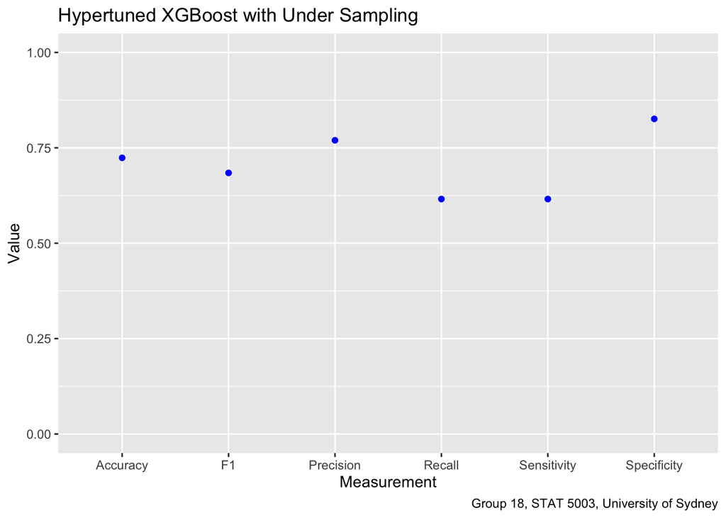

```r
x.axis <- c("Accuracy", "F1", "Precision", "Recall", "Sensitivity", "Specificity")
y.axis <- c(conf.mat$overall["Accuracy"],
            conf.mat$byClass["F1"],
            conf.mat$byClass["Precision"],
            conf.mat$byClass["Recall"],
            conf.mat$byClass["Sensitivity"],
            conf.mat$byClass["Specificity"])

d <- data.frame(x = x.axis, y = y.axis)
ggplot(d) +geom_point(aes(x, y), color = "blue") +
  ylim(0,1) +
  xlab(label = "Measurement") +
  ylab(label ="Value") +
  labs(title = "Hypertuned XGBoost with Under Sampling",
       caption = "Group 18, STAT 5003, University of Sydney")
```

### ROC Curve - Sensitivity vs Specificity

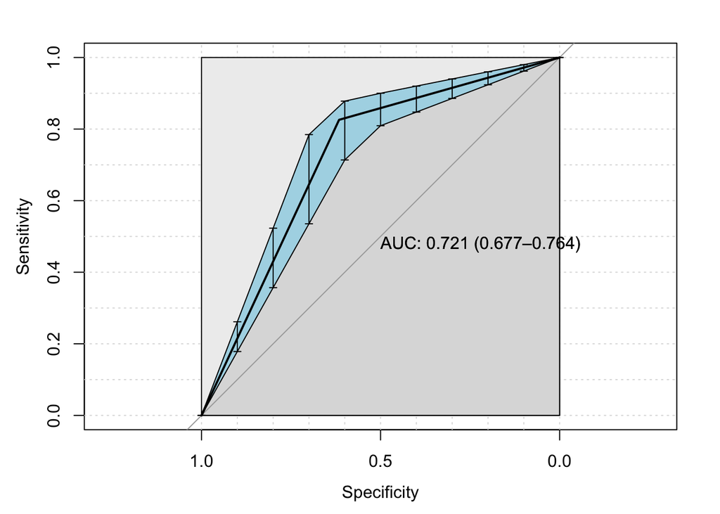

```r
pROC_obj <- roc(test.data$Offer.Accepted,
                offer.pred,
                smoothed = TRUE,
                # arguments for ci
                ci=TRUE, ci.alpha=0.9, stratified=FALSE,
                # arguments for plot
                plot=TRUE, auc.polygon=TRUE, max.auc.polygon=TRUE, grid=TRUE,
                print.auc=TRUE, show.thres=TRUE)
sens.ci <- ci.se(pROC_obj)
plot(sens.ci, type="shape", col="lightblue")
plot(sens.ci, type="bars")
```

#### Session Information

```r
# sessionInfo()
```